# Plots for Global Cost of Cash Benchmarking Deck

Ben Mazzotta

Friday, March 27, 2015

This document creates plots from the Global Cost of Cash Benchmarking Study. The plots are written for HD dimensions:

- 1280px wide
- 720px tall
- 18pt font

```r
require(ggplot2); require(data.table)
setwd("../data")
load("ccglobal.plot.Rda")


attr(costofcash$region, "levels")
```

```
## [1] "Aggregates"
## [2] "East Asia & Pacific (all income levels)"
## [3] "Europe & Central Asia (all income levels)"
## [4] "Latin America & Caribbean (all income levels)"
## [5] "Middle East & North Africa (all income levels)"
## [6] "North America"
## [7] "South Asia"
## [8] "Sub-Saharan Africa (all income levels)"
```

```r
setattr(costofcash$region, "levels", c("Aggregates","Asia Pac","Eur Asia", "Latin Am Car","Mideast NAfr", "North Amer","South Asia","SS Africa"))
costofcash[,income:=ordered(income, c("High income: OECD", "High income: nonOECD", "Upper middle income", "Lower middle income","Low income","Aggregates","Not classified"))]
```

[output not shown]

[output cut: 81 more lines]

## Warm-ups

These charts validate the graphic design in `markdown` and `ggplot2`. Once we like the design, it should be plug and play.

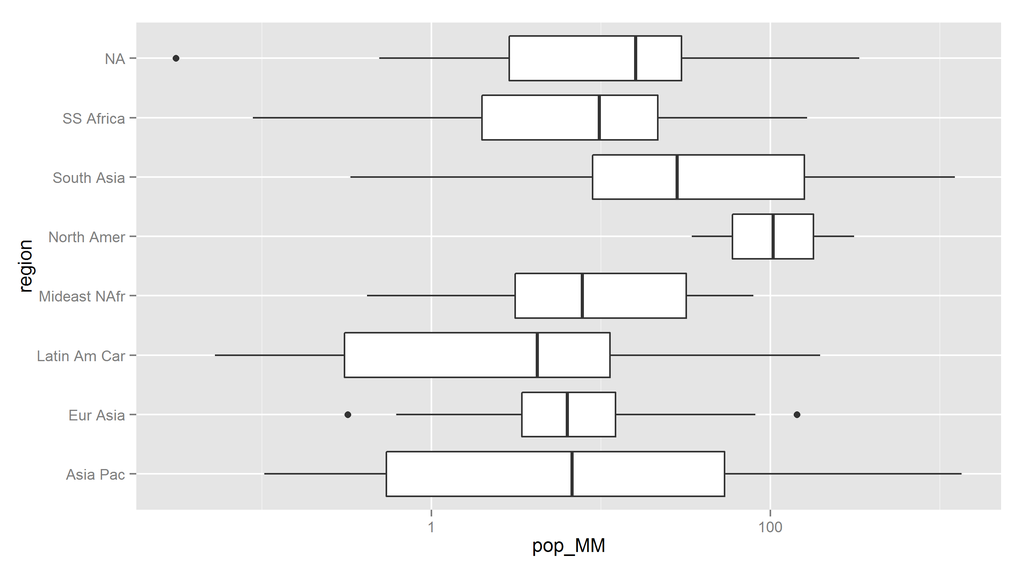

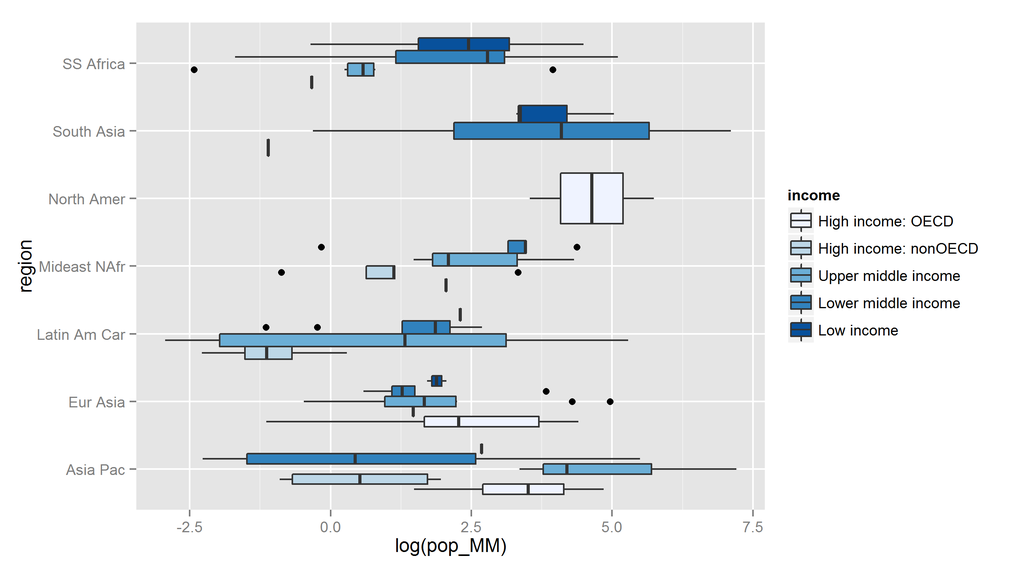

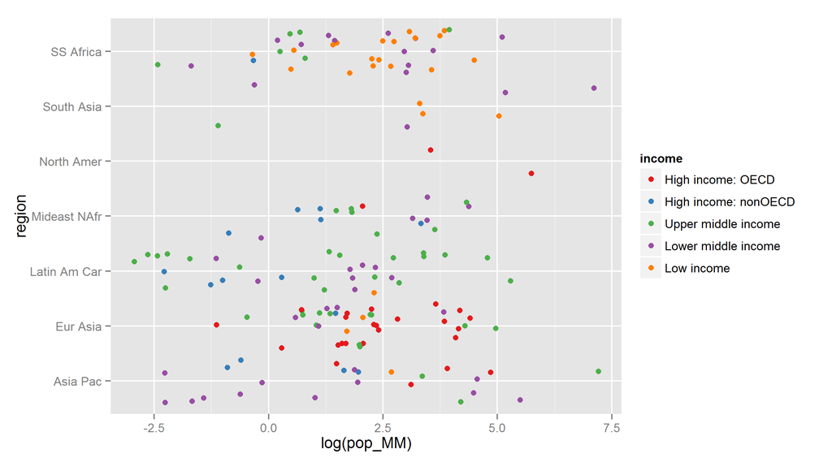

## ATM Costs

Charts planned:

- Regional boxplots for national costs
- Regional boxplots for unit costs
- Scatterplots for national vs. unit costs, by region

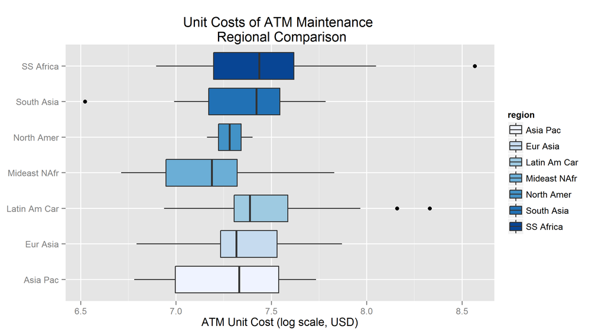

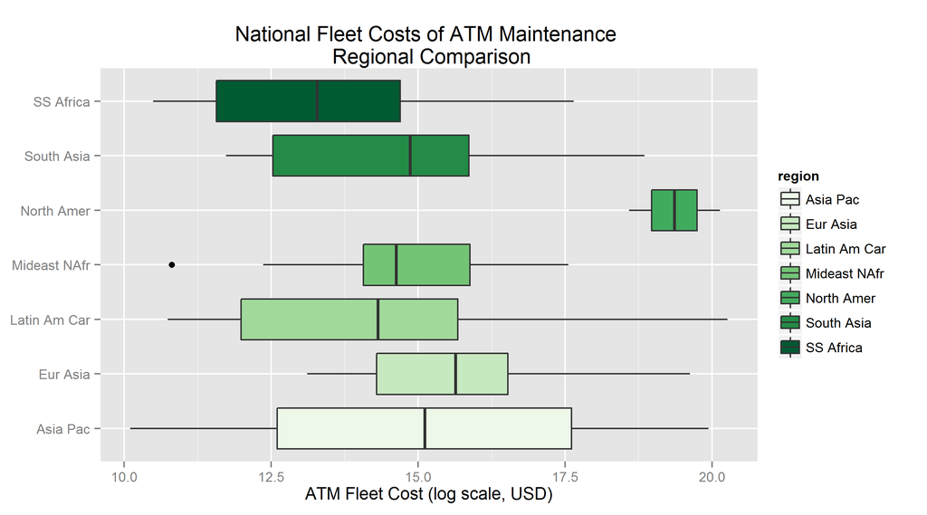

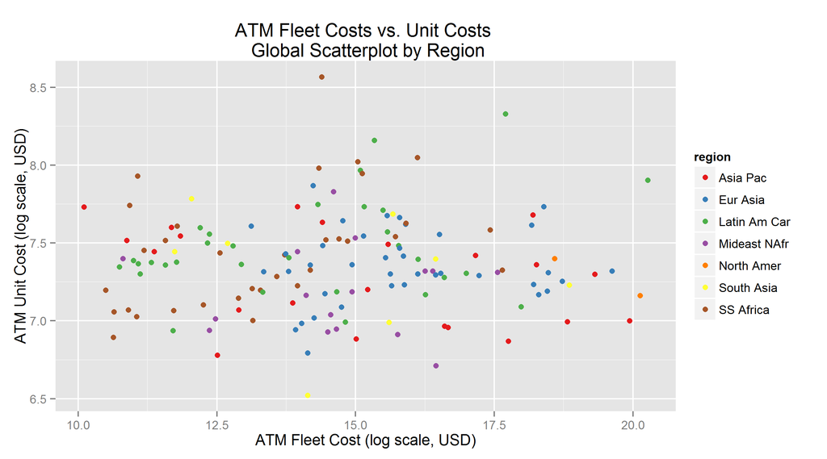

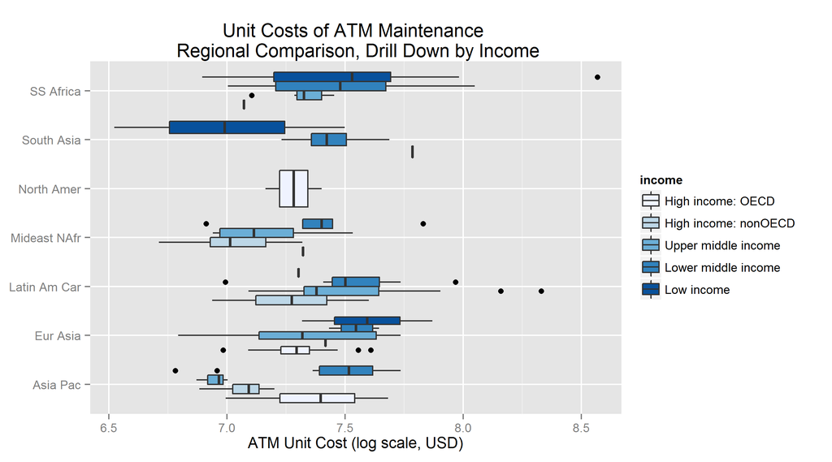

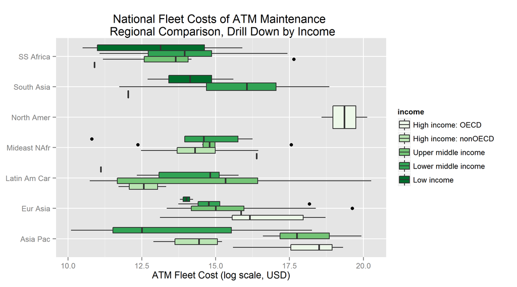

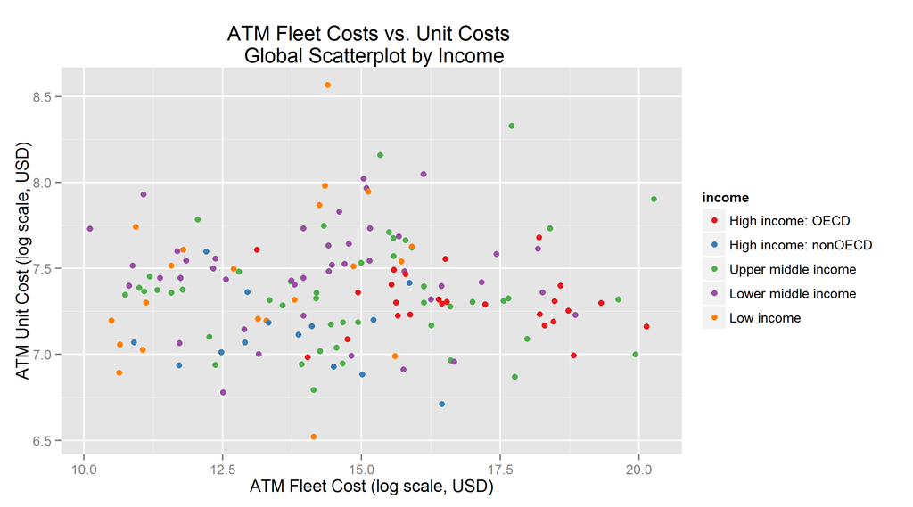

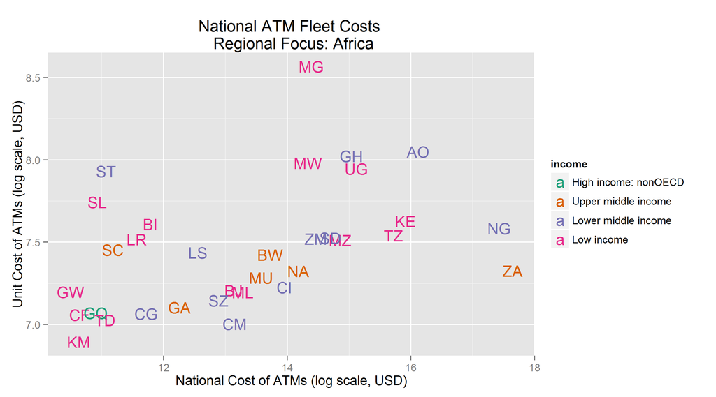

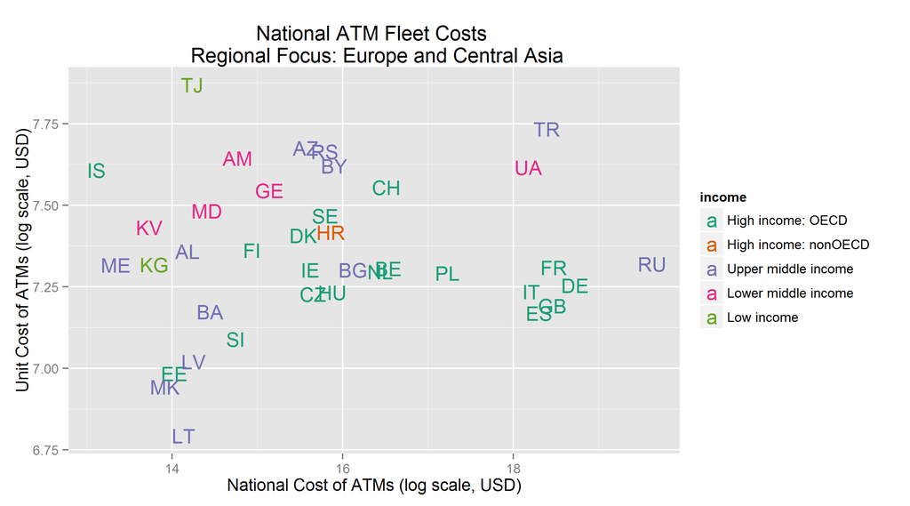

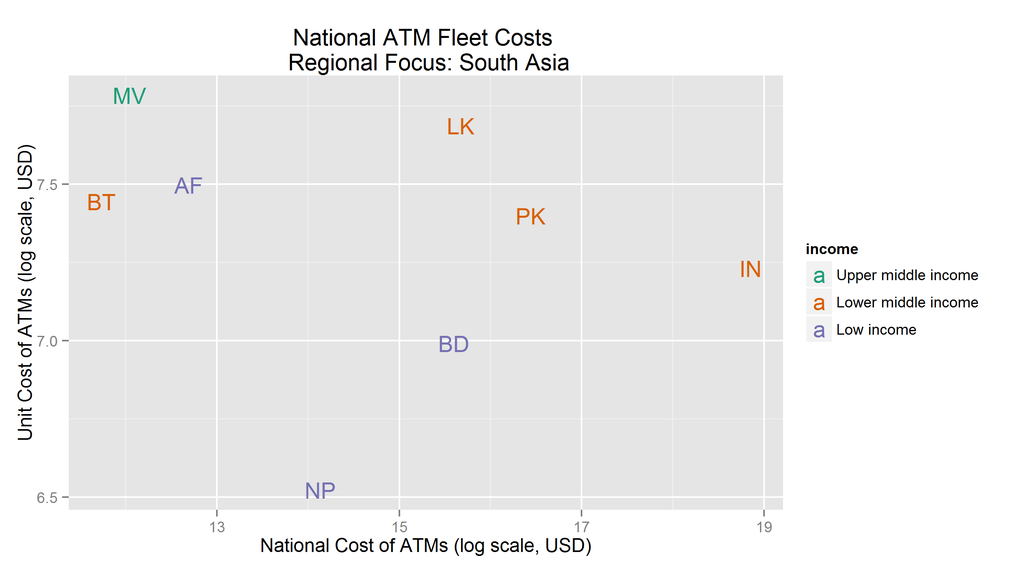

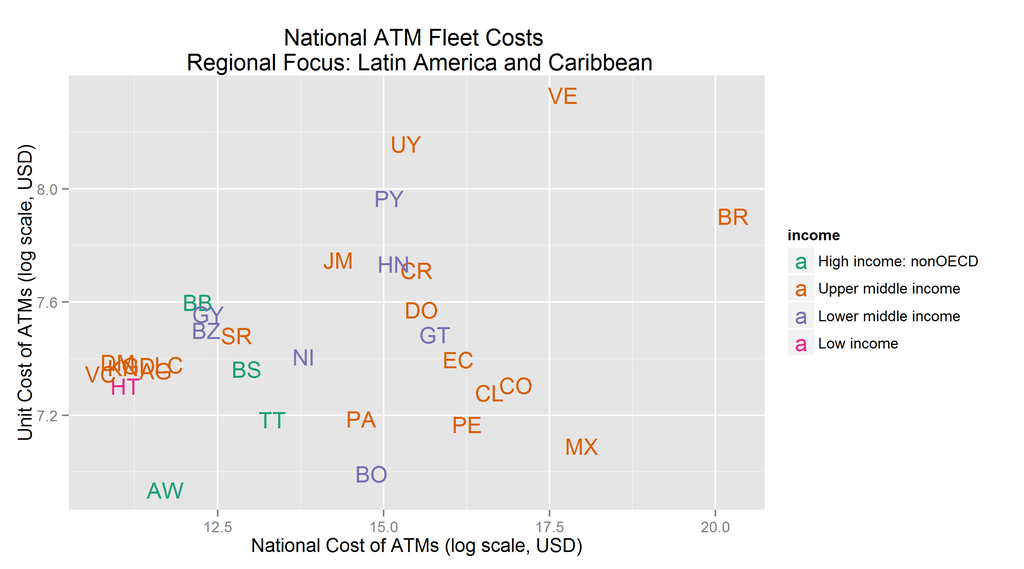

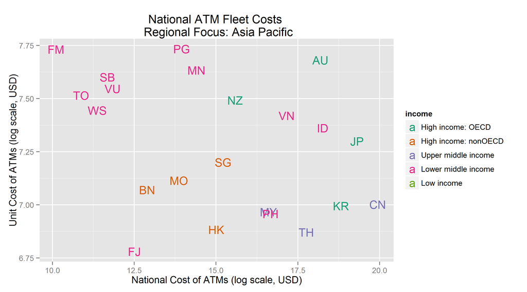

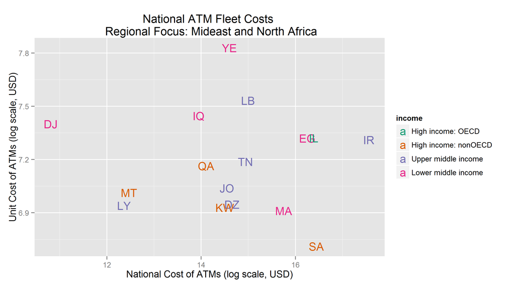

## Cash in transit

Planned charts

- World map
- Regional rankings
- Scatterplots of ATM vs CIT
- Scatterplots of CIT vs Finclusion

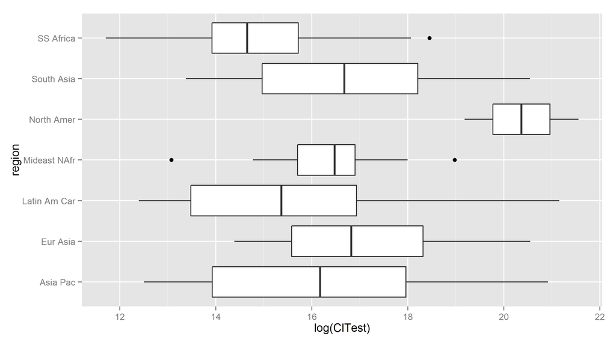

```r
plot1 <- ggplot(costofcash[!is.na(region)], aes(region, log(CITest)))
plot2 <- ggplot(costofcash[!is.na(income)], aes(income, log(CITest)))
plot3 <- ggplot(costofcash, aes(log(ATMNatlCost), log(CITest)))


## Base plots
plot1 + geom_boxplot() + coord_flip()
```

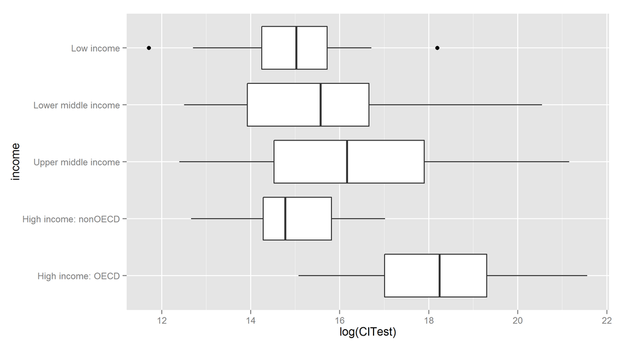

```r
plot2 + geom_boxplot() + coord_flip()
```

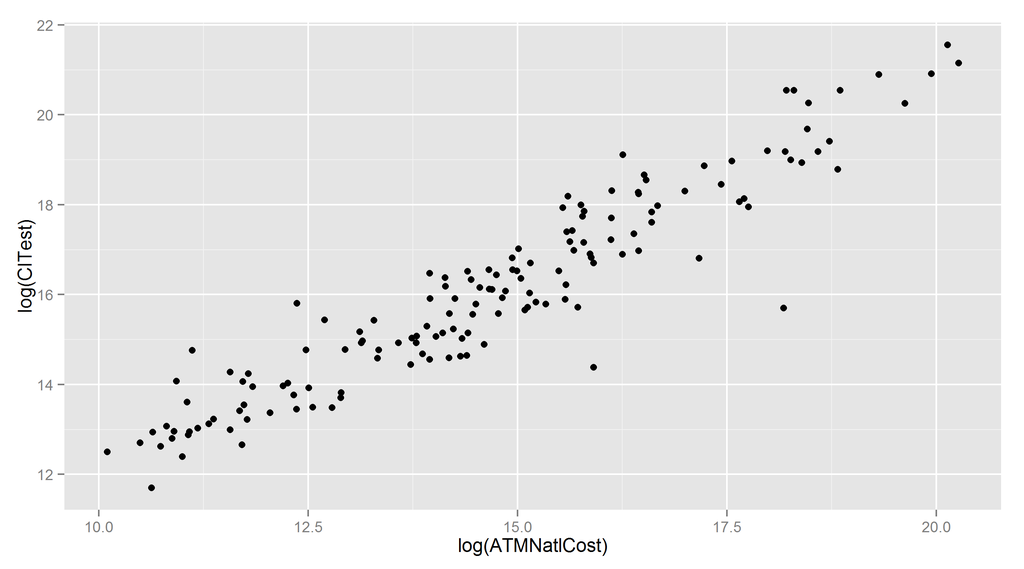

```r
plot3 + geom_point()
```

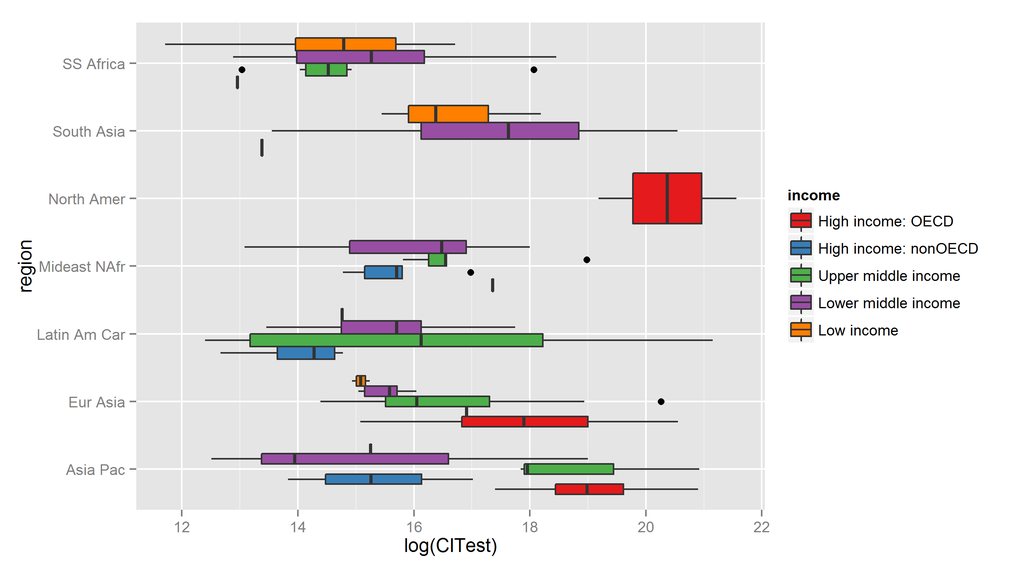

```r
## Drill down
plot1 + geom_boxplot(aes(fill=income)) + coord_flip() + scale_fill_brewer(palette="Set1")
```

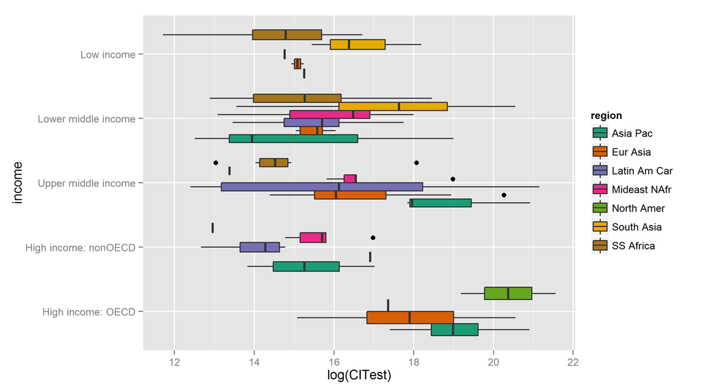

```r
plot2 + geom_boxplot(aes(fill=region)) + coord_flip() + scale_fill_brewer(palette="Dark2")
```

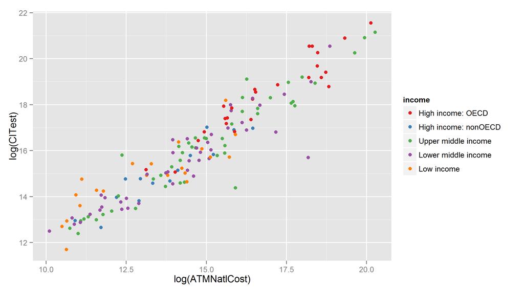

```r
plot3 + geom_point(aes(color=income))  + scale_color_brewer(palette="Set1")
```

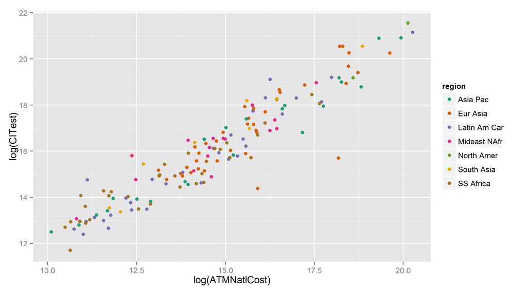

```r
plot3 + geom_point(aes(color=region)) + scale_color_brewer(palette="Dark2")
```

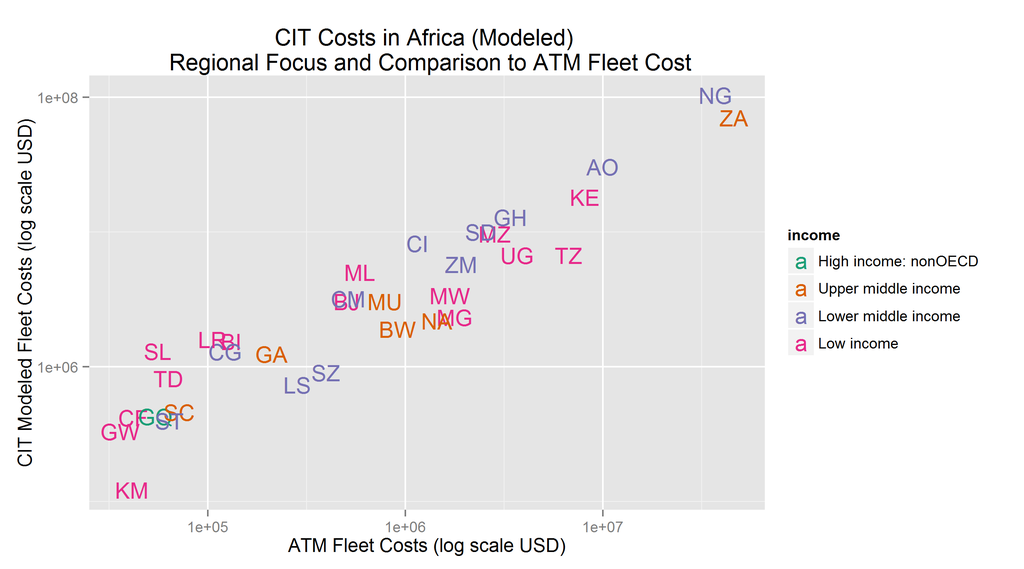

```r
##    Regional Scatterplots
qplot(ATMNatlCost, CITest, data=costofcash[region=="SS Africa"], geom="text", color=income, label=iso2c, log="xy") + scale_color_brewer(palette="Dark2") +
  labs(title="CIT Costs in Africa (Modeled) \n Regional Focus and Comparison to ATM Fleet Cost", x="ATM Fleet Costs (log scale USD)", y="CIT Modeled Fleet Costs (log scale USD)")
```

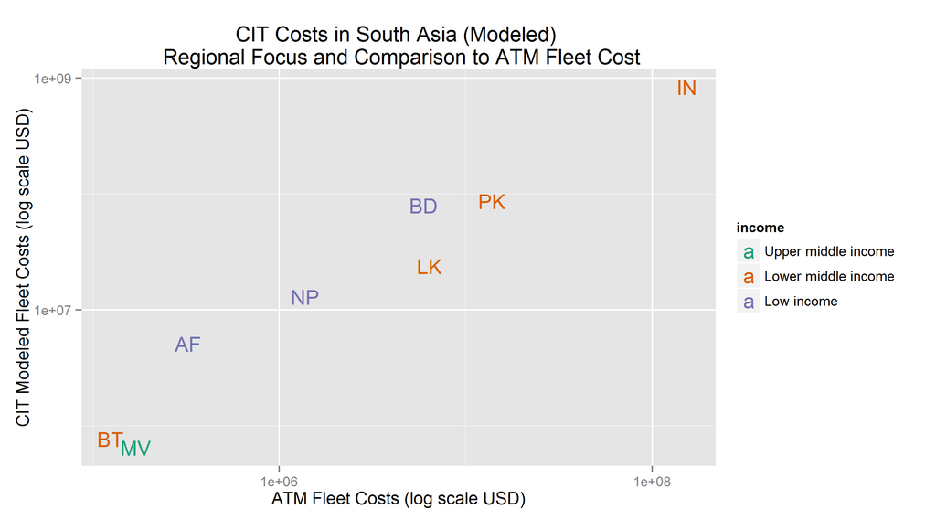

```r
qplot(ATMNatlCost, CITest, data=costofcash[region=="South Asia"], geom="text", color=income, label=iso2c, log="xy") + scale_color_brewer(palette="Dark2") +
  labs(title="CIT Costs in South Asia (Modeled) \n Regional Focus and Comparison to ATM Fleet Cost", x="ATM Fleet Costs (log scale USD)", y="CIT Modeled Fleet Costs (log scale USD)")
```

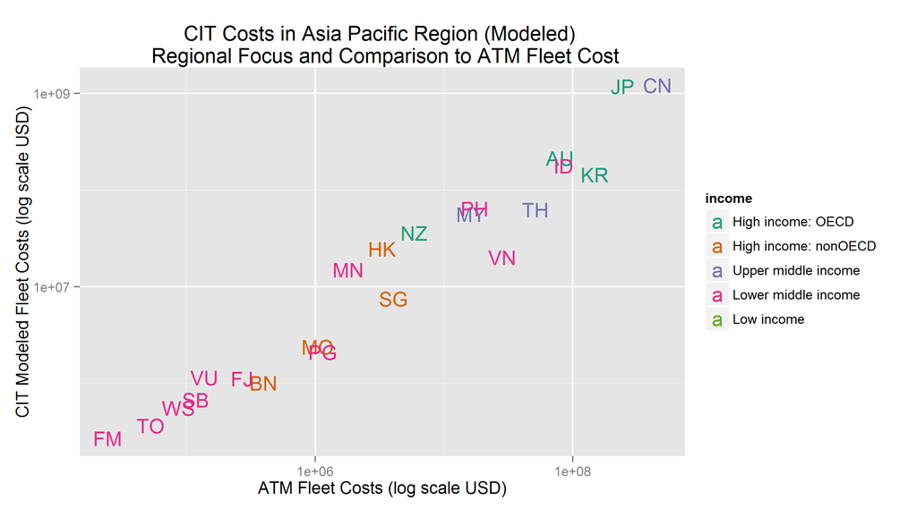

```r
qplot(ATMNatlCost, CITest, data=costofcash[region=="Asia Pac"], geom="text", color=income, label=iso2c, log="xy") + scale_color_brewer(palette="Dark2") +
  labs(title="CIT Costs in Asia Pacific Region (Modeled) \n Regional Focus and Comparison to ATM Fleet Cost", x="ATM Fleet Costs (log scale USD)", y="CIT Modeled Fleet Costs (log scale USD)")
```

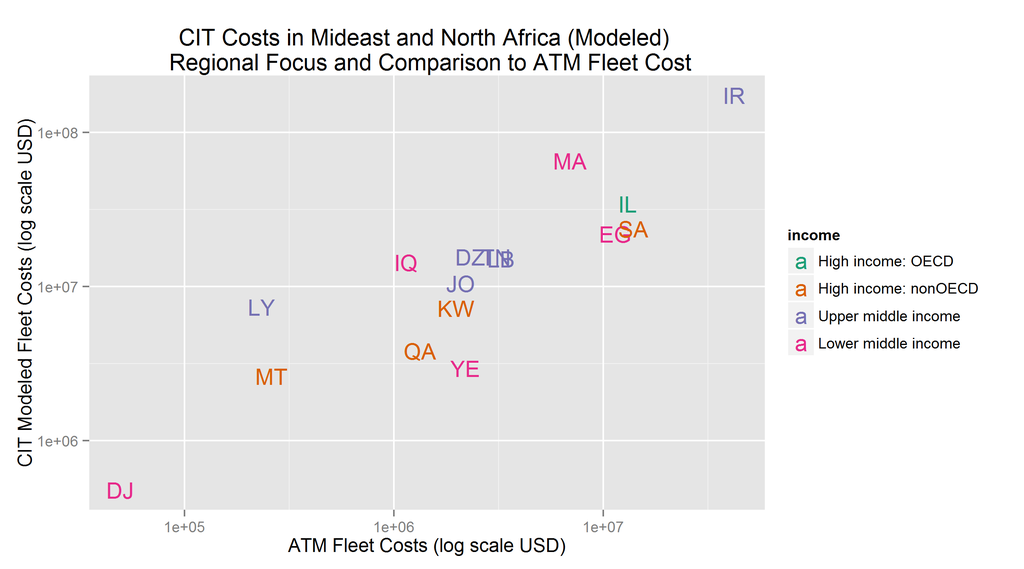

```r
qplot(ATMNatlCost, CITest, data=costofcash[region=="Mideast NAfr"], geom="text", color=income, label=iso2c, log="xy") + scale_color_brewer(palette="Dark2") +
  labs(title="CIT Costs in Mideast and North Africa (Modeled) \n Regional Focus and Comparison to ATM Fleet Cost", x="ATM Fleet Costs (log scale USD)", y="CIT Modeled Fleet Costs (log scale USD)")
```

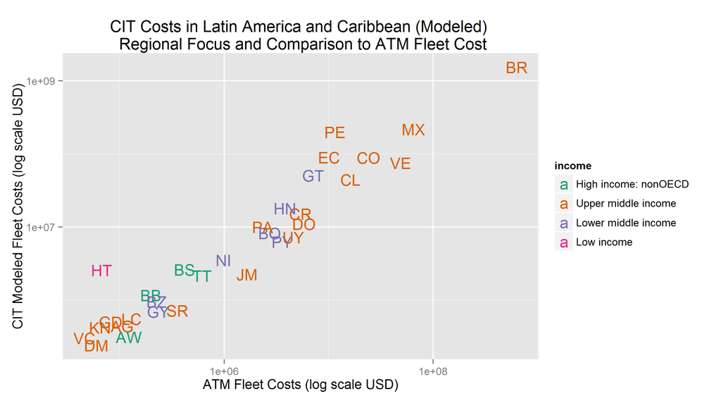

```r
qplot(ATMNatlCost, CITest, data=costofcash[region=="Latin Am Car"], geom="text", color=income, label=iso2c, log="xy") + scale_color_brewer(palette="Dark2") +
  labs(title="CIT Costs in Latin America and Caribbean (Modeled) \n Regional Focus and Comparison to ATM Fleet Cost", x="ATM Fleet Costs (log scale USD)", y="CIT Modeled Fleet Costs (log scale USD)")
```

[figure not shown]

```r
## Income Group Focus
qplot(ATMNatlCost, CITest, data=costofcash[income=="High income: nonOECD"], geom="text", color=income, label=iso2c, log="xy") + scale_color_brewer(palette="Dark2") +
  labs(title="CIT Costs in Africa (Modeled) \n Regional Focus and Comparison to ATM Fleet Cost", x="ATM Fleet Costs (log scale USD)", y="CIT Modeled Fleet Costs (log scale USD)")
```

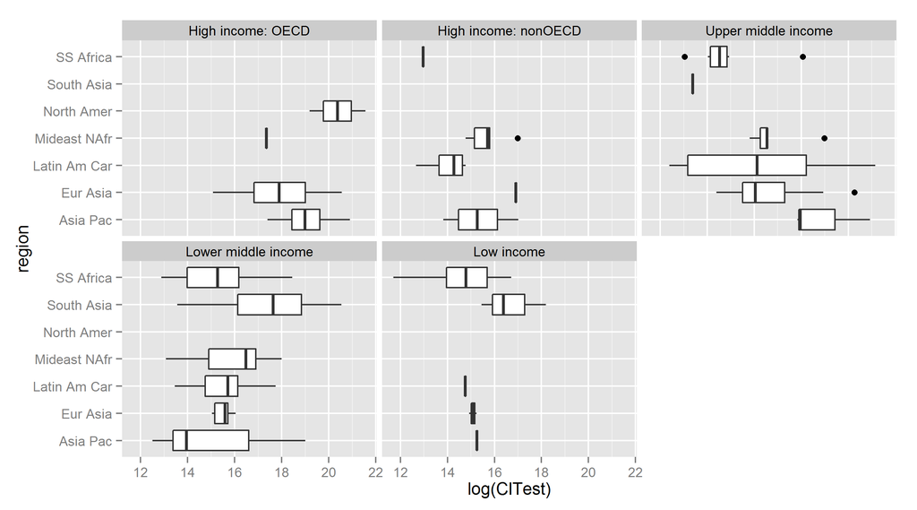

```r
## Regional focus
plot1 + geom_boxplot() + coord_flip() + facet_wrap(~income)
```

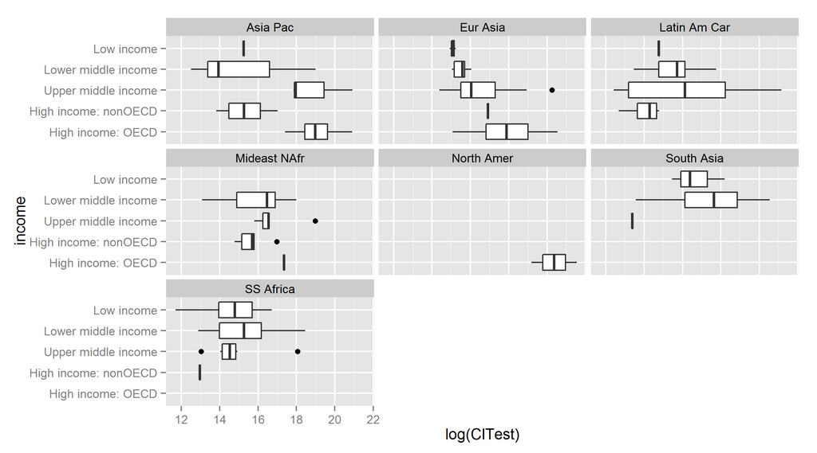

```r
plot2 + geom_boxplot() + coord_flip() + facet_wrap(~region)
```

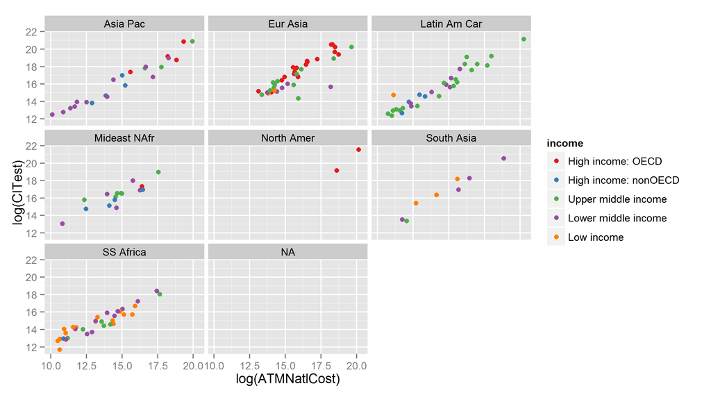

```r
plot3 + geom_point(aes(color=income))  + scale_color_brewer(palette="Set1") + facet_wrap(~region)
```

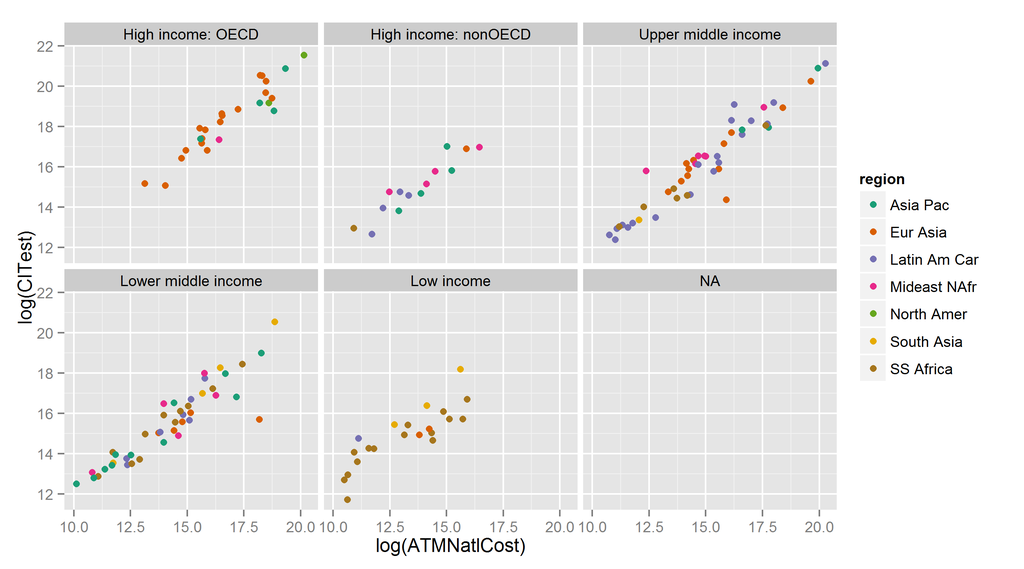

```r
plot3 + geom_point(aes(color=region))  + scale_color_brewer(palette="Dark2") + facet_wrap(~income)
```

## Consumer costs

Planned charts

- World map
- regional rankings
- Scatterplot of time vs. fees
- Regional focus
- Income bracket focus
- Scatterplot of time vs financial inclusion

```r
## Hello
```

## Currency issuance

Planned charts

- Cost of new issuance
- per capita costs vs. per capita GDP
- per capita costs vs. financial inclusion
- Value of seigniorage
- per capita costs vs. per capita GDP
- per capita costs vs. financial inclusion
- Scatterplots of seigniorage vs. issuance
- national costs
- per capita costs
- Regional focus
- income group focus

```r
## Hello
```

## Tax gap

Planned charts

- Value of tax gap
- Regional comparison
- Income group comparison
- Scatterplot vs. per capita GDP
- Scatterplots of seigniorage vs. tax gap
- national costs
- regional focus
- income group focus
- Scatterplots of currency issuance vs. tax gap
- national costs
- regional focus
- income group focus

```r
## Hello
```

## Cash hoards

Data is not yet ready.